# Poisson and binomial models in INLA

Our linear model last time was not a good fit for the data, because we have either count data (Poisson or negtaive binomial distribution) or we have binomal (proportion positive) data. So now, we fit a mixed effect model using poisson distribution

```r
library(tidyverse)
library(INLA)
bu<-read_csv("template_BU.csv")
```

When we include a dependency, we need some kind of grouping structure. We dont have one, so I add a random one. This just demonstrates how to code the factor

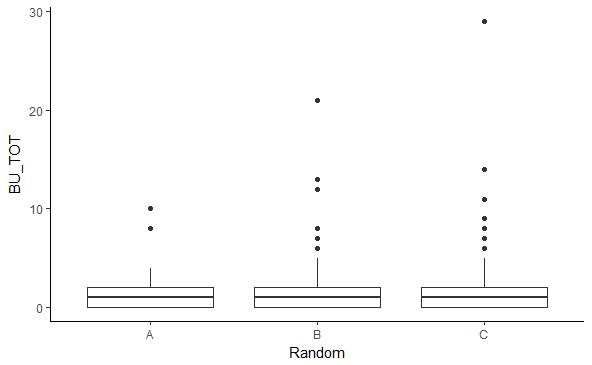

```r
bu$Random<-NA
bu$Random[1:45]<-"A"; bu$Random[46:200]<-"B"; bu$Random[201:295]<-"C"
bu$Random<-as.factor(bu$Random)
ggplot(bu)+geom_boxplot(aes(Random, BU_TOT))+theme_classic()
```

In our scenario maybe Random is actually a grouping factor of who did the sampling or which lab anaysed the sample, therefore we may suspect that there is dependency.

We will now apply a poisson model with dependency

First, write the model - for no dependency:

BU_TOT_i ~ Poissin(mu) - no hyperparameter  
E(BU_Tot_i) = mu_i  
Var(BU_Tot_i) = mu_i

mu_i = e^Cov and it is a loglink. Because is e^Cov can only predict positive numbers

First we will do with no dependency then will include dependency

For model with dependency: BU_TOT_ij ~ Poissin(mu) - no hyperparameter  
E(BU_Tot_ij) = mu_ij  
Var(BU_Tot_ij) = mu_ij  
mu_ij = Covariate stuff + a_i

where: a_i ~ N(0, sigmaRandom^2)

We now have a hyperparameter in the dependency model

```r
f0 <- BU_TOT ~ Forest + Precip_mm  + TOT_POP #no dependency
#dependency
f1 <- BU_TOT ~ Forest + Precip_mm  + TOT_POP +
              f(Random, model = "iid")
I0 <- inla(f0,
           control.compute = list(dic = TRUE),
           control.predictor = list(compute = TRUE),
           family = "poisson",
           data = bu)
I1 <- inla(f1,
           control.compute = list(dic = TRUE),
           control.predictor = list(compute = TRUE),
           family = "poisson",
           data = bu)
summary(I0)
```

```
Call:
c("inla(formula = f0, family = \"poisson\", data = bu, control.compute = list(dic = TRUE), ",  "    control.predictor = list(compute = TRUE))")

Time used:
 Pre-processing    Running inla Post-processing           Total
         6.4876          5.5105          0.8664         12.8645

Fixed effects:
               mean     sd 0.025quant 0.5quant 0.975quant    mode kld
(Intercept) -0.8780 0.8998    -2.6446  -0.8780     0.8869 -0.8780   0
Forest      -0.1599 0.7553    -1.6793  -0.1473     1.2893 -0.1219   0
Precip_mm    0.0014 0.0008    -0.0002   0.0014     0.0031  0.0014   0
TOT_POP      0.0000 0.0000     0.0000   0.0000     0.0000  0.0000   0

The model has no random effects

The model has no hyperparameters

Expected number of effective parameters(std dev): 4.003(0.00)
Number of equivalent replicates : 73.70

Deviance Information Criterion (DIC) ...: 1476.43
Effective number of parameters .........: 4.059

Marginal log-Likelihood:  -767.38
Posterior marginals for linear predictor and fitted values computed
```

```r
summary(I1)
```

```
Call:
c("inla(formula = f1, family = \"poisson\", data = bu, control.compute = list(dic = TRUE), ",  "    control.predictor = list(compute = TRUE))")

Time used:
 Pre-processing    Running inla Post-processing           Total
         5.1775          4.7717          0.7922         10.7414

Fixed effects:
               mean     sd 0.025quant 0.5quant 0.975quant    mode kld
(Intercept) -0.8139 0.9198    -2.6067  -0.8185     1.0043 -0.8262   0
Forest      -0.1649 0.7564    -1.6865  -0.1523     1.2862 -0.1269   0
Precip_mm    0.0014 0.0008    -0.0003   0.0014     0.0030  0.0014   0
TOT_POP      0.0000 0.0000     0.0000   0.0000     0.0000  0.0000   0

Random effects:
Name      Model
 Random   IID model

Model hyperparameters:
                         mean       sd 0.025quant 0.5quant 0.975quant
Precision for Random 17942.22 17220.43     245.42 12617.63   64294.69
                      mode
Precision for Random 43.72

Expected number of effective parameters(std dev): 4.112(0.2511)
Number of equivalent replicates : 71.75

Deviance Information Criterion (DIC) ...: 1476.21
Effective number of parameters .........: 4.264

Marginal log-Likelihood:  -767.43
Posterior marginals for linear predictor and fitted values computed
```

For other types of dependency, see the INLA latent models page

Final note - what if you want to see whether you have overdispersion?

You can test this but another way is to fit a negative binomial model and inspect the variance parameter

To fit a negative binomial model first we write the model

BU_TOT~ NB(mu_i, theta)

E(BU_TOT) = mu_i

Var(BU_TOT) = mu_i + mu_i^2 /theta # variance can therefore increase with the mean

```r
f2 <- BU_TOT ~ Forest + Precip_mm  + TOT_POP + MeanNDVI + MeanTemp + ShrGra+
              f(Random, model = "iid")
I2 <- inla(f2,
           control.compute = list(dic = TRUE),
           control.predictor = list(compute = TRUE),
           family = "nbinomial",
           data = bu)
summary(I2)
```

```
Call:
c("inla(formula = f2, family = \"nbinomial\", data = bu, control.compute = list(dic = TRUE), ",  "    control.predictor = list(compute = TRUE))")

Time used:
 Pre-processing    Running inla Post-processing           Total
         5.8525         17.2253          1.2276         24.3053

Fixed effects:
                mean     sd 0.025quant 0.5quant 0.975quant     mode
(Intercept) -31.5905 6.4597   -44.3325 -31.5744   -18.9504 -31.5418
Forest       -3.5217 1.7689    -7.0001  -3.5209    -0.0503  -3.5184
Precip_mm     0.0019 0.0016    -0.0012   0.0019     0.0051   0.0019
TOT_POP       0.0000 0.0000     0.0000   0.0000     0.0000   0.0000
MeanNDVI     -0.5104 1.5597    -3.5892  -0.5059     2.5403  -0.4973
MeanTemp      1.1138 0.2225     0.6787   1.1131     1.5527   1.1116
ShrGra       -0.2666 0.2355    -0.7299  -0.2665     0.1956  -0.2663
            kld
(Intercept)   0
Forest        0
Precip_mm     0
TOT_POP       0
MeanNDVI      0
MeanTemp      0
ShrGra        0

Random effects:
Name      Model
 Random   IID model

Model hyperparameters:
                                                            mean
size for the nbinomial observations (1/overdispersion) 8.777e-01
Precision for Random                                   1.882e+04
                                                              sd
size for the nbinomial observations (1/overdispersion) 1.211e-01
Precision for Random                                   1.866e+04
                                                       0.025quant
size for the nbinomial observations (1/overdispersion)     0.6661
Precision for Random                                    1282.6337
                                                        0.5quant
size for the nbinomial observations (1/overdispersion) 8.686e-01
Precision for Random                                   1.330e+04
                                                       0.975quant
size for the nbinomial observations (1/overdispersion)       1.14
Precision for Random                                     68088.13
                                                          mode
size for the nbinomial observations (1/overdispersion)    0.85
Precision for Random                                   3508.99

Expected number of effective parameters(std dev): 7.02(0.0806)
Number of equivalent replicates : 42.02

Deviance Information Criterion (DIC) ...: 1078.72
Effective number of parameters .........: 7.967

Marginal log-Likelihood:  -582.90
Posterior marginals for linear predictor and fitted values computed
```

```r
k.pd <- I2$marginals.hyperpar$`size for the nbinomial observations (1/overdispersion)`
k.pm <- inla.emarginal(function(x) x, k.pd)
k.pm #overdispersion parameter -not a problem, maybe a bit low
```

```
[1] 0.8777211
```

Lower DIC so would suggest this is a better fitting model, however we haven’t done any residual checks which of course is essential. Check the RInla help pages for details on the likelihoods but it is sparse

Finally, lets try a binomial model.

Here we are going to treat BU cases as successes and the total population as the number of trials.

Again, we start by writing the model

BU_TOT_i ~ Bin(P_i,N_i) E(BU_TOT_i) = N_i * P_i (Number of trials * probability of event) var(BU_OT_i) = N_i * P_i * (1-P_i)

P_i = exp(Covariates) / 1+exp(Covariates)

```r
f3 <- BU_TOT ~ Forest + Precip_mm  + MeanNDVI + MeanTemp + ShrGra
TOT_POP<-bu$TOT_POP
I3 <- inla(f3,
           family = "binomial",
           control.compute = list(dic = TRUE, waic = TRUE),
           control.predictor = list(compute = TRUE),
           Ntrials = TOT_POP,
           data = bu)
summary(I3)
```

```
Call:
c("inla(formula = f3, family = \"binomial\", data = bu, Ntrials = TOT_POP, ",  "    control.compute = list(dic = TRUE, waic = TRUE), control.predictor = list(compute = TRUE))" )

Time used:
 Pre-processing    Running inla Post-processing           Total
         4.6485          2.9128          0.9464          8.5078

Fixed effects:
                 mean     sd 0.025quant  0.5quant 0.975quant      mode
(Intercept) -109.3144 4.5552  -118.2466 -109.3185  -100.3680 -109.3262
Forest        -5.7540 1.1533    -8.0741   -5.7348    -3.5411   -5.6960
Precip_mm     -0.0043 0.0009    -0.0061   -0.0043    -0.0024   -0.0043
MeanNDVI       5.0403 1.0524     2.9874    5.0356     7.1173    5.0263
MeanTemp       3.8212 0.1533     3.5199    3.8213     4.1217    3.8216
ShrGra        -1.0987 0.1565    -1.4056   -1.0988    -0.7913   -1.0990
            kld
(Intercept)   0
Forest        0
Precip_mm     0
MeanNDVI      0
MeanTemp      0
ShrGra        0

The model has no random effects

The model has no hyperparameters

Expected number of effective parameters(std dev): 6.00(0.00)
Number of equivalent replicates : 49.16

Deviance Information Criterion (DIC) ...: 2596.44
Effective number of parameters .........: 5.993

Watanabe-Akaike information criterion (WAIC) ...: 2724.97
Effective number of parameters .................: 116.27

Marginal log-Likelihood:  -1322.73
Posterior marginals for linear predictor and fitted values computed
```

```r
#we have dropped the random effect here as its not useful for this model
Pi   <- I3$summary.fitted.values[,"mean"]
ExpY <- Pi * bu$TOT_POP
VarY <- bu$TOT_POP * Pi * (1 - Pi)
E1   <- (bu$BU_TOT - ExpY) / sqrt(VarY)
N    <- nrow(bu)
p <- nrow(I3$summary.fixed)
Dispersion <- sum(E1^2) / (N - p)
Dispersion
```

```
[1] 66.5776
```

Plot from the model to check the residuals

```r
par(mfrow = c(1,1), mar = c(5,5,2,2), cex.lab = 1.5)
plot(x = bu$BU_TOT,
     y = E1,
     xlab = "Total BU cases",
     ylab = "Pearson residuals")
abline(h = 0, lty = 2)
```

[figure not shown]

```r
par(mfrow = c(1,1), mar = c(5,5,2,2), cex.lab = 1.5)
```

```r
plot(E1 ~ Forest,
        data = bu)
abline(h = 0, lty = 2)
```

[figure not shown]

```r
par(mfrow = c(1,1), mar = c(5,5,2,2), cex.lab = 1.5)
```

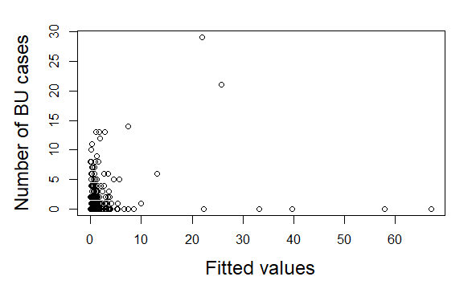

```r
plot(x = ExpY,
     y = bu$BU_TOT,
     xlab = "Fitted values",
     ylab = "Number of BU cases")
```

Doesnt look great. Lets plot our mean and standard errors anyway. Very quick and dirty apprach

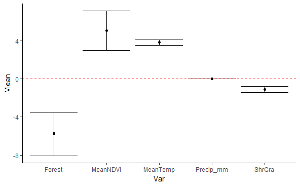

```r
round(I3$summary.fixed[, c("mean",
                              "0.025quant",
                              "0.975quant")],2)->betas
#Change the ros and headers as throws an error
betas$Var <- rownames(betas)
names(betas)<-c("Mean", "LowQ", "HiQ", "Var")
ggplot(betas[2:6,])+geom_point(aes(Var, Mean))+geom_errorbar(aes(x = Var, ymax =  HiQ, ymin =  LowQ))+geom_hline(aes(yintercept = 0), col = 2, linetype = "dashed")+theme_classic()
```

Remove the intercept because it makes it hard to see the other variables.

Going to continue with the binomial model.